# Homeworks2

Liu Dingding

2021/12/16

## Question 8.2

Implement the bivariate Spearman rank correlation test for independence as a permutation test. The Spearman rank correlation test statistic can be obtained from function cor with method = “spearman”. Compare the achieved significance level of the permutation test with the p-value reported by cor.test on the same samples.

## Anwser

This example tests whether the distributions of petal length and sepal length of iris setosa are independent. To implement a permutation test, write a function to compute the replicates of the test statistic that takes as its first argument the data matrix and as its second argument the permutation vector. The permutation test procedure for independence permutes the row indices of one of the samples.

```r
cor.sprman<-function(z,ix){
  #compute the Spearman rank correlation test statistic
  #z:two samples x and y
  #ix:a permutation of row indices of y
  x<-z[,1]
  y<-z[ix,2]#permutate rows of y
  return(cor(x,y,method = "spearman"))
}
```

Large absolute values of cor.sprman support the alternative hypothesis that the two samples is not irrelevant.

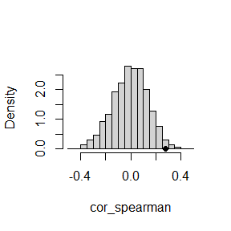

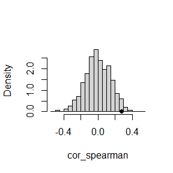

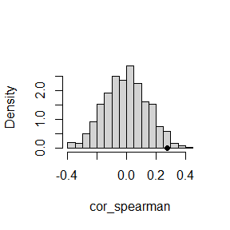

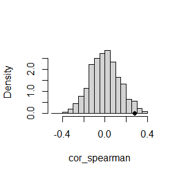

```r
set.seed(123)
library(boot)
z<-as.matrix(iris[1:50,c(1,3)])#Sepal.length and Petal.length
asl<-numeric(4)
asl<-replicate(4,expr={#compute achieved significance level of the permutation test
  boot.obj<-boot(data=z,statistic=cor.sprman,R=999,sim="permutation")
  tb<-c(boot.obj$t0,boot.obj$t)
  hist(tb,nclass="scott",xlab="cor_spearman",main="",freq=FALSE,)
  points(boot.obj$t0,0,cex=1,pch=16)
  mean(abs(tb)>=boot.obj$t0)
})
```

We implement permutation tests four times.The four histograms of replicates of the Spearman rank correlation test statistic are shown in above Figure with points of the observation for the statistic($t0).

```r
print(asl)
```

```
## [1] 0.057 0.059 0.046 0.051
```

The achieved significance levels of the permutation test are $0.057,0.059,0.046, 0.051$,so the null hypothesis of independence is rejected at $\alpha = 0.10$.

```r
x<-z[,1]#Sepal.length
y<-z[,2]#Petal.length
c<-cor.test(x,y,alternative="two.sided",method="spearman",exact = FALSE)
print(c$p.value)
```

```
## [1] 0.04985095
```

The p-value reported by cor.test on the same samples Sepal.length and Petal.length is $0.04985095$.

Compared with the p-value by cor.test,the four achieved significance levels we get(0.057,0.059,0.046, 0.051) is varying.

## Question

Design experiments for evaluating the performance of the NN, energy, and ball methods in various situations.

(1)Unequal variances and equal expectations

(2)Unequal variances and unequal expectations

(3)Non-normal distributions: t distribution with 1 df (heavy-tailed distribution), bimodel distribution (mixture of two normal distributions)

4. Unbalanced samples (say, 1 case versus 10 controls)

Note: The parameters should be chosen such that the powers are distinguishable (say, range from 0.3 to 0.8)

## Anwser

The approximate permutation energy test is implemented in eqdist.etest in the energy package.And R package “Ball” gives Ball statistic. So firstly we write a function to compute Nearest neighbor statistic:

```r
library(MASS)
library(RANN)#for nn2 function
library(energy)#for eqdist.etest()
library(Ball)
knn<-function(z,ix,sizes,k){
  #compute k-Nearest neighbor statistic
  n1<-sizes[1]
  n2<-sizes[2]
  n<-n1+n2
  if(is.vector(z))z<-data.frame(z)
  z<-z[ix,]
  NN<-nn2(z,k=k+1)
  block1<-NN$nn.idx[1:n1,-1]
  block2<-NN$nn.idx[(n1+1):n,-1]
  i1<-sum(block1<n1+.5)
  i2<-sum(block2>n1+.5)
  return((i1+i2)/(k*n))
}
knn.test<-function(z,sizes,k){
  boot.obj <- boot(data=z,statistic=knn,R=999, sim="permutation", sizes = sizes,k=k)
  tb<- c(boot.obj$t0,boot.obj$t)
  p.value <- mean(tb>=boot.obj$t0)
  list(statistic=boot.obj$t0,p.value=p.value)
}
```

1. Unequal variances and equal expectations

we produce random variables from the below two multi-normal distributions: $N(\mu_1,\Sigma_1)$and$N(\mu_2,\Sigma_2)$ where
$$\mu_1=\mu_2=(0,0,0)$$
$$\Sigma_1=\begin{pmatrix}
1&0&0\\
0&1&0\\
0&0&1\\
\end{pmatrix}
\Sigma_2=\begin{pmatrix}
3&0&0\\
0&2&0\\
0&0&3\\
\end{pmatrix}$$

Then we implement three permutation tests:

```r
mu2<-mu1<-c(0,0,0)
s1<-diag(3)
s2<-matrix(c(3,0,0,0,2,0,0,0,3),nrow=3,ncol=3)
n1=n2=15
n <- n1+n2
N = c(n1,n2)
k=3
m=100
powr<- numeric(3)#store power for three kinds tests
set.seed(11)
p.values<-replicate(m,expr = {
  ##compute p-values for nn,energy,ball methods
  x<- mvrnorm(n1,mu1,s1)
  y<- mvrnorm(n2,mu2,s2)
  z<- rbind(x,y)
  p1 <- knn.test(z,sizes=N,k)$p.value#NN method
  p2<- eqdist.etest(z,sizes=N,R=999)$p.value#energy method
  p3 <- bd.test(x,y,num.permutations=999)$p.value#ball method
  list(p1,p2,p3)
})
for(i in 1:3){
  powr[i]=mean(as.numeric(p.values[i,])<0.05)##set alpha as 0.05
}
print(c(power_nn=powr[1],power_energy=powr[2],power_ball=powr[3]))
```

```
##     power_nn power_energy   power_ball
##         0.18         0.16         0.63
```

From the result we can see that the power of Ball method is obviously higher than the other two methods.And NN method performs better than energy method.

2. Unequal variances and unequal expectations

We produce random variables from the below two multi-normal distributions: $N(\mu_1,\Sigma_1)$and$N(\mu_2,\Sigma_2)$ where
$$\mu_1=(0,0,0),\mu_2=(1,1,1)$$
$$\Sigma_1=\begin{pmatrix}
1&0&0\\
0&1&0\\
0&0&1\\
\end{pmatrix}
\Sigma_2=\begin{pmatrix}
2&0&0\\
0&2&0\\
0&0&3\\
\end{pmatrix}$$

Then we implement three permutation tests:

```r
mu1<-c(0,0,0);mu2<-c(1,1,1)
s1<-diag(3)
s2<-matrix(c(2,0,0,0,2,0,0,0,3),nrow=3,ncol=3)
n1=n2=15
n <- n1+n2
N = c(n1,n2)
k=3
m=100
powr<- numeric(3)#store power for three kinds tests
set.seed(12)
p.values<-replicate(m,expr = {
  ##compute p-values for nn,energy,ball methods
  x<- mvrnorm(n1,mu1,s1)
  y<- mvrnorm(n2,mu2,s2)
  z<- rbind(x,y)
  p1 <- knn.test(z,sizes=N,k)$p.value#NN method
  p2<- eqdist.etest(z,sizes=N,R=999)$p.value#energy method
  p3 <- bd.test(x,y,num.permutations=999)$p.value#ball method
  list(p1,p2,p3)
})
for(i in 1:3){
  powr[i]=mean(as.numeric(p.values[i,])<0.05)##set alpha as 0.05
}
print(c(power_nn=powr[1],power_energy=powr[2],power_ball=powr[3]))
```

```
##     power_nn power_energy   power_ball
##         0.74         0.91         0.93
```

From the result we can see that Ball method performs best .And NN method performs worse than energy method.

3. Non-normal distributions: t distribution with 1 df (heavy-tailed distribution), bimodel distribution (mixture of two normal distributions)

We produce random variables from the below two non-normal distributions:t distribution

Then we implement three permutation tests:

```r
n1=n2=20
n <- n1+n2
N = c(n1,n2)
k=3
m=100
powr<- numeric(3)#store power for three kinds tests
set.seed(111)
p.values<-replicate(m,expr = {
  ##compute p-values for nn,energy,ball methods
  x<-as.matrix(rt(n1,1,2));y<-as.matrix(rt(n2,2,5))
  z<- rbind(x,y)
  p1 <- knn.test(z,sizes=N,k)$p.value#NN method
  p2<- eqdist.etest(z,sizes=N,R=999)$p.value#energy method
  p3 <- bd.test(x,y,num.permutations=999)$p.value#ball method
  list(p1,p2,p3)
})
for(i in 1:3){
  powr[i]=mean(as.numeric(p.values[i,])<0.05)##set alpha as 0.05
}
print(c(power_nn=powr[1],power_energy=powr[2],power_ball=powr[3]))
```

```
##     power_nn power_energy   power_ball
##         0.65         0.52         0.81
```

From the result,the Ball method is also of best performance and energy method performs worst.

Next,We produce random variables from the below two non-normal distributions:bimodel distribution
$$0.3N(0,1)+0.7N(1,4),0.5N(0,4)+0.5N(1,1),$$

Then we implement three permutation tests:

```r
n1=n2=20
n <- n1+n2
N = c(n1,n2)
k=3
m=100
powr<- numeric(3)#store power for three kinds tests
set.seed(111)
p.values<-replicate(m,expr = {
  ##compute p-values for nn,energy,ball methods
  e1<-sample(0:1,size=20,replace=TRUE,prob = c(0.7,0.3))
  x<-e1*rnorm(n1,0,1)+(1-e1)*rnorm(n1,1,2)#x is data from bimodel distribution
  x<-as.matrix(x)
  e2<-sample(0:1,size=20,replace=TRUE,prob = c(0.5,0.5))
  y<-e2*rnorm(n2,0,2)+(1-e2)*rnorm(n2,1,1)#y is data from bimodel distribution
  y<-as.matrix(y)
  z<- rbind(x,y)
  p1 <- knn.test(z,sizes=N,k)$p.value#NN method
  p2<- eqdist.etest(z,sizes=N,R=999)$p.value#energy method
  p3 <- bd.test(x,y,num.permutations=999)$p.value#ball method
  list(p1,p2,p3)
})
for(i in 1:3){
  powr[i]=mean(as.numeric(p.values[i,])<0.05)##set alpha as 0.05
}
print(c(power_nn=powr[1],power_energy=powr[2],power_ball=powr[3]))
```

```
##     power_nn power_energy   power_ball
##         0.07         0.07         0.07
```

4. Unbalanced samples:

We produce two samples from the below two multi-normal distributions: $N(\mu_1,\Sigma_1)$and$N(\mu_2,\Sigma_2)$ where
$$\mu_1=\mu_2=(0,0,0)$$
$$\Sigma_1=\begin{pmatrix}
1&0&0\\
0&1&0\\
0&0&1\\
\end{pmatrix}
\Sigma_2=\begin{pmatrix}
3&0&0\\
0&2&0\\
0&0&3\\
\end{pmatrix}$$

Then we implement three permutation tests,but the two sample sizes is 10 vs 100:

```r
mu2<-mu1<-c(0,0,0)
s1<-diag(3)
s2<-matrix(c(3,0,0,0,2,0,0,0,3),nrow=3,ncol=3)
n1=10;n2=100
n <- n1+n2
N = c(n1,n2)
k=3
m=100
powr<- numeric(3)#store power for three kinds tests
set.seed(11)
p.values<-replicate(m,expr = {
  ##compute p-values for nn,energy,ball methods
  x<- mvrnorm(n1,mu1,s1)
  y<- mvrnorm(n2,mu2,s2)
  z<- rbind(x,y)
  p1 <- knn.test(z,sizes=N,k)$p.value#NN method
  p2<- eqdist.etest(z,sizes=N,R=999)$p.value#energy method
  p3 <- bd.test(x,y,num.permutations=999)$p.value#ball method
  list(p1,p2,p3)
})
for(i in 1:3){
  powr[i]=mean(as.numeric(p.values[i,])<0.05)##set alpha as 0.05
}
print(c(power_nn=powr[1],power_energy=powr[2],power_ball=powr[3]))
```

```
##     power_nn power_energy   power_ball
##         0.07         0.02         0.79
```

From the result,we can see that Ball method is still of best performance;it’s power is much higher than the other methods.NN method is slightly better than energy.

## Question 9.3

1. Use the Metropolis-Hastings sampler to generate random variables from a standard Cauchy distribution. Discard the first 1000 of the chain, and compare the deciles of the generated observations with the deciles of the standard Cauchy distribution (see qcauchy or qt with df=1). Recall that a $Cauchy(\theta, \eta)$ distribution has density function
   $$f(x) =\frac{1} {\theta\pi(1 + [(x − \eta)/\theta]2)}, −\infty<x< \infty, \theta> 0.$$
   The standard Cauchy has the $Cauchy(\theta = 1, \eta= 0)$ density. (Note that the standard Cauchy density is equal to the Student t density with one degree of freedom.)
2. Use the Gelman-Rubin method to monitor convergence of the chain, and run the chain until it converges approximately to the target distribution according to $\hat{R} < 1.2$.

## Anwser

A standard Cauchy distribution has density function $f(x) =\frac{1} {\pi(1 + x^2)}, −\infty<x< \infty.$ i.e. $\theta=1,\eta=0$

For the proposal distribution, try the normal distribution $N(X_t,\sigma^2)$.

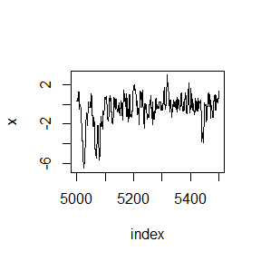

```r
    set.seed(10)
    m <- 10000
    x <- numeric(m)#初始化随机向量
    x[1] <- rnorm(1)
    #建议分布选择方差为1的正态分布,从标准正态分布中生成X0并储存在x[1]中
    k <- 0
    u <- runif(m)

    for (i in 2:m) {
        xt <- x[i-1]
        y <- rnorm(1,mean=xt,sd=1)#从N(Xt,1)=N(x[i-1],1)中生成y
        num <- dcauchy(y) * dnorm(xt, mean=y,sd=1)
        den <- dcauchy(xt) * dnorm(y, mean=xt,sd=1)
        if (u[i] <= num/den){
          x[i] <- y
        } else {
          x[i] <- xt
          k <- k+1     #y is rejected
        }
    }
    index<-5000:5500
    y1 <- x[index]
    plot(index, y1, type="l", main="", ylab="x")
```

The above figure present Part of a chain generated by a Metropolis-Hastings sampler of a standard Cauchy distribution

Standard Cauchy distribution has cdf:$F(x)=\frac{arctan x}{\pi}+\frac{1}{2},−\infty<x< \infty.$

So we can conduct an explicit formula for the quantiles of the Standard Cauchy distribution as:
$$x_q=F^{-1}(q)=tan(\pi(q-0.5))$$

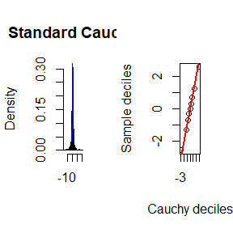

```r
    b <- 1001      #discard the burn-in sample
    y <- x[b:m]
    a <- seq(0.1,0.9,0.1)
    QC<- tan(pi*(a-0.5)) #quantiles of Cauchy
    Q <- quantile(x, a) #the deciles of the generated chain
    par(mfrow=c(1,2))
    hist(y, breaks="scott", main="Standard Cauchy", xlab="", freq=FALSE)
    lines(QC, dcauchy(QC),col='blue')
    qqplot(QC, Q, main="",xlab="Cauchy deciles", ylab="Sample deciles")
    abline(0,1,col='red',lwd=2)
```

The histogram of the generated sample with the Standard Cauchy density superimposed is shown in left figure and the QQ plot is shown in the right Figure. From the plot, it appears that the sample Deciles are in approximate agreement with the theoretical Deciles.

Next we ues the Gelman-Rubin method to monitor the convergence of the above chain.

```r
    Gelman.Rubin <- function(psi) {
        # psi[i,j] is the statistic psi(X[i,1:j])
        # for chain in i-th row of X
        psi <- as.matrix(psi)
        n <- ncol(psi)
        k <- nrow(psi)

        psi.means <- rowMeans(psi)     #row means
        B <- n * var(psi.means)        #between variance est.
        psi.w <- apply(psi, 1, "var")  #within variances
        W <- mean(psi.w)               #within est.
        v.hat <- W*(n-1)/n + (B/n)     #upper variance est.
        r.hat <- v.hat / W             #G-R statistic
        return(r.hat)
        }

    cauchy.chain <- function( sigma,N, X1) {
        #generates a Metropolis chain for stantard cauchy distribution
        #with Normal(X[t], 1) proposal distribution
        #and starting value X1
        x <- rep(0, N)
        x[1] <- X1
        u <- runif(N)

        for (i in 2:N) {
            xt <- x[i-1]
            y <- rnorm(1, mean=xt, sd=sigma)     #candidate point
            r1 <- dcauchy(y) * dnorm(xt, y, sd=sigma)
            r2 <- dcauchy(xt) * dnorm(y, xt, sd=sigma)
            r <- r1 / r2
            if (u[i] <= r) x[i] <- y else
                 x[i] <- xt
            }
        return(x)
        }


    k <- 4          #number of chains to generate
    n <- 15000      #length of chains
    b <- 1000       #burn-in length

    #choose overdispersed initial values
    x0 <- c(-10, -5, 5, 10)

    #generate the chains
    set.seed(11)
    sigma<-seq(1.5,2.5,0.1)
    GR<-numeric(length(sigma))
    for(j in 1:length(sigma)){
      X <- matrix(0, nrow=k, ncol=n)
      for (i in 1:k)
        X[i, ] <- cauchy.chain(sigma[j],n, x0[i])

      #compute diagnostic statistics
      psi <- t(apply(X, 1, cumsum))
      for (i in 1:nrow(psi))
        psi[i,] <- psi[i,] / (1:ncol(psi))
      GR[j]=Gelman.Rubin(psi)
    }
    print(GR)
```

```
##  [1] 1.330653 3.374922 2.664715 2.111193 1.099508 1.177350 1.418482 2.475350
##  [9] 1.669565 1.936160 1.832877
```

According $\hat{R}<1.2$,so we choose sigma=1.9.

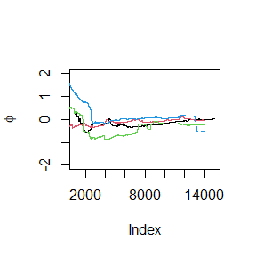

```r
    #plot psi for the four chains
    sigma=1.9
    X <- matrix(0, nrow=k, ncol=n)
      for (i in 1:k)
        X[i, ] <- cauchy.chain(sigma,n, x0[i])

      #compute diagnostic statistics
      psi <- t(apply(X, 1, cumsum))
      for (i in 1:nrow(psi))
        psi[i,] <- psi[i,] / (1:ncol(psi))
    for (i in 1:k)
      if(i==1){
        plot((b+1):n,psi[i, (b+1):n],ylim=c(-2,2), type="l",
            xlab='Index', ylab=bquote(phi))
      }else{
        lines(psi[i, (b+1):n], col=i)
      }
```

```r
    print(Gelman.Rubin(psi))
```

```
## [1] 1.148132
```

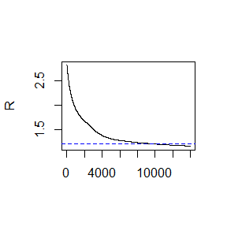

```r
    par(mfrow=c(1,1)) #restore default

    #plot the sequence of R-hat statistics
    rhat <- rep(0, n)
    for (j in (b+1):n)
        rhat[j] <- Gelman.Rubin(psi[,1:j])
    plot(rhat[(b+1):n], type="l", xlab="", ylab="R")
    abline(h=1.2, lty=2,col="blue")
```

The plot of $\hat{R}$ is shown in Figure for time 1001 to 15000. The value of $\hat{R}$ is below 1.2 within 12000 iterations.

## Question 9.8

1. Consider the bivariate density
   $$f(x, y) \varpropto {n\choose x}y^{x+a−1}(1 − y)^
   {n−x+b−1}, x = 0, 1, . . . , n, 0 ≤ y ≤ 1.$$
   It can be shown that for fixed a, b, n, the conditional distributions are Binomial(n, y) and Beta(x + a, n − x + b). Use the Gibbs sampler to generate a chain with target joint density f(x, y).

2.use the Gelman-Rubin method to monitor convergence of the chain, and run the chain until it converges approximately to the target distribution according to $\hat{R} < 1.2$.

## Anwser

The conditional densities of the given distribution is:$f(x|y)$ is the density of Binomial(n, y),$f(y|x)$ is the density of Beta(x + a, n − x + b).

```r
#initialize constants and parameters
N <- 5000 #length of chain
burn <- 1000 #burn-in length
X <- matrix(0, N, 2) #the chain, a bivariate sample
a=2;b=3;n=10#初始化参数
x1=5;x2=0.5
###### generate the chain #####
set.seed(15)
X[1, ] <- c(x1, x2) #initialize
for (i in 2:N) {
x2 <- X[i-1, 2]
X[i, 1] <- rbinom(1, size=n, prob=x2)
x1 <- X[i, 1]
X[i, 2] <- rbeta(1, x1+a, n-x1+b)
}
bu <- burn + 1
x <- X[bu:N, ]

cat('Means: ',round(colMeans(x),2))
```

```
## Means:  4.06 0.41
```

```r
cat('Standard errors: ',round(apply(x,2,sd),2))
```

```
## Standard errors:  2.45 0.2
```

```r
cat('Correlation coefficients: ', round(cor(x[,1],x[,2]),2))
```

```
## Correlation coefficients:  0.81
```

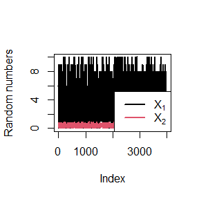

```r
plot(x[,1],type='l',col=1,lwd=2,xlab='Index',ylab='Random numbers')
lines(x[,2],col=2,lwd=2)
legend('bottomright',c(expression(X[1]),expression(X[2])),col=1:2,lwd=2)
```

Next we ues the Gelman-Rubin method to monitor the convergence of the above chain.

```r
    Gelman.Rubin <- function(psi) {
        # psi[i,j] is the statistic psi(X[i,1:j])
        # for chain in i-th row of X
        psi <- as.matrix(psi)
        n <- ncol(psi)
        k <- nrow(psi)

        psi.means <- rowMeans(psi)     #row means
        B <- n * var(psi.means)        #between variance est.
        psi.w <- apply(psi, 1, "var")  #within variances
        W <- mean(psi.w)               #within est.
        v.hat <- W*(n-1)/n + (B/n)     #upper variance est.
        r.hat <- v.hat / W             #G-R statistic
        return(r.hat)
        }

        x.chain <- function( N, X1,yvalue) {
        #generates a Metropolis chain for Binormial distribution
        #with poisson(Xt) proposal distribution
        #and starting value X1
        x <- rep(0, N)
        x[1] <- X1
        u <- runif(N)

        for (i in 2:N) {
            xt <- x[i-1]
            y <- rpois(1,lambda=xt)     #candidate point
            r1 <- dbinom(y,size=10,prob=yvalue) * dpois(xt, y)#n=10
            r2 <- dbinom(xt,size=10,prob=yvalue) * dpois(y, xt)
            r <- r1 / r2
            if (u[i] <= r) x[i] <- y else
                 x[i] <- xt
            }
        return(x)
        }
        y.chain <- function( N, X1,xvalue) {
        #generates a Metropolis chain for stantard cauchy distribution
        #with chisq(X[t], 1) proposal distribution
        #and starting value X1
        x <- rep(0, N)
        x[1] <- X1
        u <- runif(N)

        for (i in 2:N) {
            xt <- x[i-1]
            y <- rchisq(1, df=xt)     #candidate point
            r1 <- dbeta(y,xvalue+2,13-xvalue) * dchisq(xt, y)#a=2,b=3
            r2 <- dbeta(xt,xvalue+2,13-xvalue) * dchisq(y, xt)#a=2,b=3
            r <- r1 / r2
            if (u[i] <= r) x[i] <- y else
                 x[i] <- xt
            }
        return(x)
        }


    k <- 4          #number of chains to generate
    n <- 15000      #length of chains
    b <- 1000       #burn-in length

    #choose overdispersed initial values
    x0 <- c(1,2,3,4)
    y0<-c(0.2,0.3,0.4,0.5)
    #generate the chains
    set.seed(16)
      X <-Y<- matrix(0, nrow=k, ncol=n)
      for (i in 1:k){
        X[i, ] <- x.chain(n, x0[i],yvalue=0.8)
        Y[i, ] <- y.chain(n, y0[i],xvalue=3)}
      #compute diagnostic statistics
      psi1 <- t(apply(X, 1, cumsum))
      psi2 <- t(apply(Y, 1, cumsum))
      for (i in 1:nrow(psi1)){
        psi1[i,] <- psi1[i,] / (1:ncol(psi1))
        psi2[i,] <- psi2[i,] / (1:ncol(psi2))}
    print(c(Gelman.Rubin(psi1),Gelman.Rubin(psi2)))
```

```
## [1] 1.070058 1.098311
```

Two Marginal distributions (we choose x=3;y=0.8) satisfy that $\hat{R}<1.2$.

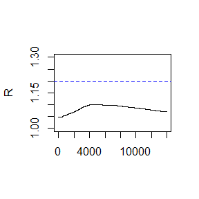

```r
    #plot the sequence of R-hat statistics
    rhat1<- rhat2<- rep(0, n)
    for (j in (b+1):n){
        rhat1[j] <- Gelman.Rubin(psi1[,1:j])
        rhat2[j] <- Gelman.Rubin(psi2[,1:j])
        }
    plot(rhat1[(b+1):n], type="l", xlab="", ylab="R",ylim = c(1,1.3))
    abline(h=1.2, lty=2,col="blue")
```

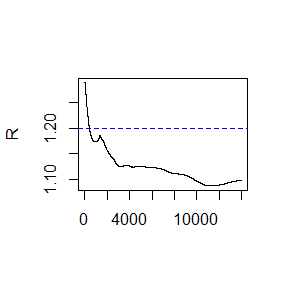

```r
    plot(rhat2[(b+1):n], type="l", xlab="", ylab="R")
    abline(h=1.2, lty=2,col="blue")
```

we choose x=3 to monitor the convergence of distribution f(x,3) and y=0.8 to monitor the convergence of distribution f(0.8,y).The two figures tell us the chains are converging fast.The two values of $\hat{R}$ are both below 1.2 within 2000 iterations.

## Question 11.3

1. Write a function to compute the kth term in
   $$\sum_{k=0}^{\infty}\frac{(-1)^k}{k!2^k}\frac{\parallel a\parallel^{2k+2}}{(2k + 1)(2k + 2)}\frac{\Gamma(\frac{d+1}{2})\Gamma(k+\frac{3}{2})}{\Gamma(k+\frac{d}{2}+1)},$$
   where $d\ge1$ is an integer, a is a vector in $R^d$, and $\parallel ·\parallel$ denotes the Euclidean norm. Perform the arithmetic so that the coefficients can be computed for (almost) arbitrarily large k and d. (This sum converges for all $a \in R^d$).
2. Modify the function so that it computes and returns the sum.
3. Evaluate the sum when $a = (1, 2)^T$ .

## Anwser

```r
options(warn=-1)
##compute terms
fa<-function(k,a){
  ##compute kth term for the series
  d<-length(a)
  i<-rep(c(1,-1),length=k)#1 or -1 for k
  ik<-i[k]
  k<-k-1
  c1=exp(lgamma((d+1)/2)+lgamma(k+3/2)-lgamma(k+d/2+1))
  c2<-factorial(k)*2^k*(2*k+1)*(2*k+2)
  c<-ik*c1*norm(a)^(2*k+2)/c2
  return(c)
}


##compute sum
fb<-function(k,a){
  ##return sum for k terms
  d<-length(a)
  i<-rep(c(1,-1),length=k)#1 or -1 for k
  K<-0:(k-1)
  c1=exp(lgamma((d+1)/2)+lgamma(K+3/2)-lgamma(K+d/2+1))
  c2<-factorial(K)*2^K*(2*K+1)*(2*K+2)
  c<-i*c1*norm(a)^(2*K+2)/c2
  return(sum(c))
}

a<-matrix(c(1,2))
print(c(fa(1,a),fa(2,a),fa(3,a)))#terms for k=0,1,2
```

```
## [1]  3.534292 -1.988039  1.491029
```

```r
f<-k<-0:25
for(i in 1:length(k))
  f[i]<-fb(k[i],a)
print(f[c(5,10,15,20,25)])#sums until k=4,9,14,19,24
```

```
## [1] 1.988902 2.415488 2.405410 2.405440 2.405440
```

```r
knitr::kable(rbind(k[15:25],f[15:25]))
```

| 14.00000 | 15.000000 | 16.000000 | 17.00000 | 18.000000 | 19.00000 | 20.00000 | 21.00000 | 22.00000 | 23.00000 | 24.00000 |
| --- | --- | --- | --- | --- | --- | --- | --- | --- | --- | --- |
| 2.40541 | 2.405447 | 2.405438 | 2.40544 | 2.405439 | 2.40544 | 2.40544 | 2.40544 | 2.40544 | 2.40544 | 2.40544 |

## Question 11.4

Find the intersection points $A(k)$ in $(0,\sqrt k)$ of the curves
$$S_{k-1}(a)=P\Bigg(t(k-1)>\sqrt{\frac{a^2(k-1)}{k-a^2}}\Bigg)$$
and
$$S_{k}(a)=P\Bigg(t(k)>\sqrt{\frac{a^2k}{k+1-a^2}}\Bigg)$$
for $k = 4 : 25, 100, 500, 1000$, where $t(k)$ is a Student t random variable with $k$ degrees of freedom.

## Anwser

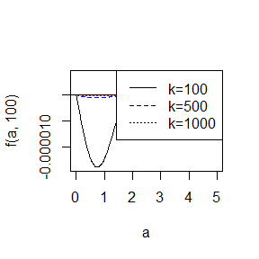

```r
##function for S_k(a)
sk<-function(a,k){
  x<-sqrt(a^2*k/(k+1-a^2))
  pt(x,df=k,lower.tail=FALSE)

}
f<-function(a,k) sk(a,k)-sk(a,k-1)#xlim is (0,sqrt(k))

K<-c(4 : 25,100, 500, 1000)
root1<-numeric(length(K))
##first to find the approximation of the root for f
a<-seq(0,5,0.01)
plot(a,f(a,100),lty=1,type="l",xlim=c(0,5))
lines(a,f(a,500),lty=2,col="blue",xlim=c(0,5))
lines(a,f(a,1000),lty=3,col="red",xlim=c(0,5))
abline(h=0)
legend("topright", legend=c("k=100", "k=500", "k=1000"), lty=1:3)
```

We can get a appropriate interval $(1,2)$ contained root value.

```r
for(i in 1:length(K)){
  k<-K[i]
  out<-uniroot(function(a){
    sk(a,K[i])-sk(a,K[i]-1)},
    c(1,2))
  root1[i]<-out$root
}
knitr::kable(rbind(K[1:12],root1[1:12]))
```

| 4.000000 | 5.000000 | 6.000000 | 7.00000 | 8.000000 | 9.000000 | 10.00000 | 11.000000 | 12.000000 | 13.000000 | 14.00000 | 15.000000 |
| --- | --- | --- | --- | --- | --- | --- | --- | --- | --- | --- | --- |
| 1.492103 | 1.533556 | 1.562744 | 1.58443 | 1.601185 | 1.614521 | 1.62539 | 1.634419 | 1.642038 | 1.648554 | 1.65419 | 1.659114 |

```r
knitr::kable(rbind(K[-(1:12)],root1[-(1:12)]))
```

| 16.000000 | 17.000000 | 18.000000 | 19.00000 | 20.000000 | 21.000000 | 22.000000 | 23.00000 | 24.000000 | 25.000000 | 100.000000 | 500.000000 | 1000.000000 |
| --- | --- | --- | --- | --- | --- | --- | --- | --- | --- | --- | --- | --- |
| 1.663452 | 1.667304 | 1.670745 | 1.67384 | 1.676637 | 1.679178 | 1.681496 | 1.68362 | 1.685572 | 1.687373 | 1.720608 | 1.729756 | 1.730908 |

## Question 11.5

Write a function to solve the equation
$$\frac{2\Gamma(\frac{k}{2})}{\sqrt{\pi(k-1)}\Gamma(\frac{k-1}{2})}\int_0^{c_{k-1}}\Bigg(1+\frac{u^2}{k-1}\Bigg)^{-\frac{k}{2}}du\\
=\frac{2\Gamma(\frac{k+1}{2})}{\sqrt{\pi k}\Gamma(\frac{k}{2})}\int_0^{c_{k}}\Bigg(1+\frac{u^2}{k}\Bigg)^{-\frac{k+1}{2}}du$$
for a,where
$$c_k=\sqrt{\frac{a^2k}{k+1-a^2}}.$$
Compare the solutions with the points A(k) in Exercise 11.4.

## Anwser

Reduce $\frac{2}{\sqrt\pi}$ to get the follwing equation:
$$\frac{\Gamma(\frac{k}{2})}{\sqrt{(k-1)}\Gamma(\frac{k-1}{2})}\int_0^{c_{k-1}}\Bigg(1+\frac{u^2}{k-1}\Bigg)^{-\frac{k}{2}}du\\
=\frac{\Gamma(\frac{k+1}{2})}{\sqrt{ k}\Gamma(\frac{k}{2})}\int_0^{c_{k}}\Bigg(1+\frac{u^2}{k}\Bigg)^{-\frac{k+1}{2}}du$$

First we write a function to compute the integration in the equation

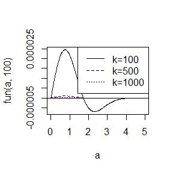

```r
fck<-function(a,k){
  ##compute integration
  ck<-sqrt(a^2*k/(k+1-a^2))
  v<-integrate(function(u){
    (1+u^2/k)^(-(k+1)/2)},
    lower = 0,upper = ck,
    rel.tol = .Machine$double.eps^0.25)$value
  return(exp(lgamma((k+1)/2)-lgamma(k/2))/sqrt(k)*v)
}

##write function to compute the right minus the left
fun<-function(a,k){
  ##a is a numeric vector
  m<-length(a)
  x<-1:m
  for(i in 1:m)
    x[i]<-fck(a[i],k)-fck(a[i],k-1)
  return(x)
}

K<-s.root<-c(4 : 25,100, 500, 1000)
a<-seq(0,5,0.01)
plot(a,fun(a,100),lty=1,type="l",xlim=c(0,5))
lines(a,fun(a,500),lty=2,col="blue",xlim=c(0,5))
lines(a,fun(a,1000),lty=3,col="red",xlim=c(0,5))
abline(h=0)
legend("topright", legend=c("k=100", "k=500", "k=1000"), lty=1:3)
```

We can get a appropriate interval $(1,2)$ contained root value.

```r
root2<-numeric(length(K))
for(i in 1:length(K)){
  k<-K[i]
  out<-uniroot(function(a){
    fck(a,k)-fck(a,k-1)},
    c(1,2))
  root2[i]<-out$root
}
knitr::kable(rbind(K[1:12],root2[1:12],root1[1:12]))
```

| 4.000000 | 5.000000 | 6.000000 | 7.00000 | 8.000000 | 9.000000 | 10.00000 | 11.000000 | 12.000000 | 13.000000 | 14.00000 | 15.000000 |
| --- | --- | --- | --- | --- | --- | --- | --- | --- | --- | --- | --- |
| 1.492103 | 1.533556 | 1.562744 | 1.58443 | 1.601185 | 1.614521 | 1.62539 | 1.634419 | 1.642038 | 1.648554 | 1.65419 | 1.659114 |
| 1.492103 | 1.533556 | 1.562744 | 1.58443 | 1.601185 | 1.614521 | 1.62539 | 1.634419 | 1.642038 | 1.648554 | 1.65419 | 1.659114 |

```r
knitr::kable(rbind(K[-(1:12)],root2[-(1:12)],root1[-(1:12)]))
```

| 16.000000 | 17.000000 | 18.000000 | 19.00000 | 20.000000 | 21.000000 | 22.000000 | 23.00000 | 24.000000 | 25.000000 | 100.000000 | 500.000000 | 1000.000000 |
| --- | --- | --- | --- | --- | --- | --- | --- | --- | --- | --- | --- | --- |
| 1.663452 | 1.667304 | 1.670745 | 1.67384 | 1.676637 | 1.679178 | 1.681496 | 1.68362 | 1.685572 | 1.687373 | 1.720608 | 1.729756 | 1.730907 |
| 1.663452 | 1.667304 | 1.670745 | 1.67384 | 1.676637 | 1.679178 | 1.681496 | 1.68362 | 1.685572 | 1.687373 | 1.720608 | 1.729756 | 1.730908 |

```r
#root1 are the roots of ex 11.4;root2 are the roots of ex 11.5
```

The solutions of this question are the same as the points A(k) in Exercise 11.4

## Question

Suppose $T_1, . . . , T_n$ are i.i.d. samples drawn from the exponential distribution with expectation $\lambda$. Those values greater than τ are not observed due to right censorship, so that the observed values are $Y_i = T_iI(T_i \le \tau ) + \tau I(Ti > \tau ),i = 1, . . . , n.$ Suppose $\tau = 1$ and the observed $Y_i$ values are as follows:
$$0.54, 0.48, 0.33, 0.43, 1.00, 1.00, 0.91, 1.00, 0.21, 0.85$$
Use the E-M algorithm to estimate $\lambda$, compare your result with the observed data MLE (note: $Y_i$ follows a mixture distribution)

## Anwser

Rearrange the sample $Y_i$ putting 1 at the end as follows :
$$0.54, 0.48, 0.33, 0.43, 0.91, 0.21, 0.85,1.00, 1.00,1.00$$
We can conduct that $T_i=Y_i,i=1,...,7;Y_j=1.00,j=8,9,10$

The density is
$$f(x)=\lambda e^{-\lambda x},x>0.$$
$$P(T>1)= e^{-\lambda }.$$
Suppose $y_i,i=1,...,10$ are observed values.

**Observed data likelihood:**
$$L(\lambda|y_1,...,y_{10})=\prod_{i=1}^{7}f(y_i)\cdot\prod_{j=8}^{10}P(T_j>1)\\=\lambda^{-7}\cdot exp\{-\lambda^{-1}\cdot(\sum_{i=1}^{7}y_i+3)\}$$
$$l(\lambda|y_1,...,y_{10})=-7log\lambda-\lambda^{-1}\cdot(\sum_{i=1}^{7}y_i+3)$$

From $\frac{\partial l}{\partial \lambda}=0$,we can get **the observed data MLE** :
$$\lambda_0=\frac{\sum_{i=1}^{7}y_i+3}{7}$$

**Complete data likelihood:**
$$l(\lambda;y_1,...,y_{7},T_8,T_9,T_{10})=-10log\lambda-\lambda^{-1}\cdot(\sum_{i=1}^{7}y_i+\sum_{j=8}^{10}T_j)$$
**Kth E-step:** Initiate $\lambda$ with $\lambda_k$,then caculate

$$l_k(\lambda;y_1,...,y_{10})=E_{\lambda_k}[l(\lambda;y_1,...,y_{7},T_8,T_9,T_{10}|y_1,...,y_{7},T_j\ge1,j=8,9,10)]
\\=-10log\lambda-\lambda^{-1}\cdot(\sum_{i=1}^{7}y_i+\sum_{j=8}^{10}E_{\lambda_k}[T_j|T_j\ge1])
\\=-10log\lambda-\lambda^{-1}\cdot(\sum_{i=1}^{7}y_i+3(\lambda_k+1))$$

where
$$E_{\lambda}[T_j|T_j\ge1]=\frac{\int_1^\infty \lambda xe^{-\lambda x}dx}{P(T>1)}
\\=\frac{\int_1^\infty \lambda xe^{-\lambda x}dx}{e^{-\lambda}}
\\=\frac{(\lambda+1)e^{-\lambda}}{e^{-\lambda}}
\\=\lambda+1$$
**Kth M-step:**maximize $l_k(\lambda;y_1,...,y_{10})$,from $\frac{\partial l_k}{\partial \lambda}=0$,we can get :
$$\lambda_{k+1}=\frac{\sum_{i=1}^{7}y_i+3(\lambda_k+1)}{10}$$

The sequence $\{\lambda_k\}$ has convergence.

$$\lambda=\frac{\sum_{i=1}^{7}y_i+3(\lambda+1)}{10}\Rightarrow\lambda
=\frac{\sum_{i=1}^{7}y_i+3}{7}$$

The convergence of $\{\lambda_k\}$ is $\frac{\sum_{i=1}^{7}y_i+3}{7}$.

**The EM estimator is exactly the observed data MLE!**

Then implement EM algorithm

```r
library(nloptr)
y<-c(0.54, 0.48, 0.33, 0.43, 0.91, 0.21, 0.85,1.00, 1.00,1.00)

eval.lam<-function(lam,lam0,data=y){
  c<-10*log(lam)+(sum(data[1:7])+3*lam0+3)/lam
  return(c)
}

N<-10000
l0<-as.vector(0.8)##initial est. for lambdas
tol<-.Machine$double.eps^0.5
opts = list("algorithm"="NLOPT_LN_COBYLA",
             "xtol_rel"=tol)
d=1
j=1
while(abs(d)>tol){
  out<-nloptr(x0=0.8,
              eval_f=eval.lam,
              lb=0,ub=10,
              opts = opts,
              lam0=l0[j],data=y)
  d<-l0[j]-out$solution
  l0<-c(l0,out$solution)
  j<-j+1
}
print(l0)#lambdas
k<-length(l0)
lam.EM<-(sum(y[1:7])+3)/7
knitr::kable(cbind(k,l0[k],lam.EM),col.names = c("iteration times","test result","theoretical values"))
```

[output not shown]

## Question 1

Why are the following two invocations of lapply() equivalent?

$trims <- c(0, 0.1, 0.2, 0.5)\\x <- rcauchy(100)\\lapply(trims, function(trim) mean(x, trim = trim))\\lapply(trims, mean, x = x)$

## Anwser

```r
set.seed(17)
trims <- c(0, 0.1, 0.2, 0.5)
x <- rcauchy(100)
unlist(lapply(trims, function(trim) mean(x, trim = trim)))
```

```
## [1] -1.1661587 -0.4849343 -0.2858702 -0.1701439
```

```r
unlist(lapply(trims, mean, x = x))
```

```
## [1] -1.1661587 -0.4849343 -0.2858702 -0.1701439
```

From the result of code,they are the same.

This is because the pieces of x are always supplied as the first argument to f and trims are supplied as the second argument “trim” to f.

## Question 2

For each model in the previous two exercises, extract $R^2$ using the function below.

```r
rsq <- function(mod) summary(mod)$r.squared
```

## Anwser

In exercise 3,we have:

```r
attach(mtcars)

formulas <- list(
  mpg ~ disp,
  mpg ~ I(1 / disp),
  mpg ~ disp + wt,
  mpg ~ I(1 / disp) + wt
)

#method 1 for excercise 3
l3=lapply(formulas, function(x) lm(formula = x, data = mtcars))
rsq3.1=lapply(l3,rsq)
unlist(rsq3.1)
```

```
## [1] 0.7183433 0.8596865 0.7809306 0.8838038
```

```r
#method 2 for excercise 3
rsq3.2<-lapply(formulas, function(x){
  mod<-lm(formula = x, data = mtcars)
  rsq(mod)}
  )
unlist(rsq3.2)
```

```
## [1] 0.7183433 0.8596865 0.7809306 0.8838038
```

```r
bootstraps <- lapply(1:10, function(i) {
  rows <- sample(1:nrow(mtcars), rep = TRUE)
  mtcars[rows, ]
})
#method 1 for excercise 4
l4<-lapply(bootstraps, function(x) lm(formula =mpg ~ disp, data = x))
rsq4.1=lapply(l4,rsq)#method 1 for excercise 4
unlist(rsq4.1)
```

```
##  [1] 0.7841864 0.5543517 0.7707085 0.6712950 0.7118090 0.6483252 0.7149986
##  [8] 0.6245985 0.7192072 0.6804647
```

```r
#method 2 for excercise 4
rsq4.2<-lapply(bootstraps, function(x){
  l<-lm(formula =mpg ~ disp, data = x)
  rsq(l)
})
unlist(rsq4.2)
```

```
##  [1] 0.7841864 0.5543517 0.7707085 0.6712950 0.7118090 0.6483252 0.7149986
##  [8] 0.6245985 0.7192072 0.6804647
```

## Question 3

Use vapply() to: a) Compute the standard deviation of every column in a numeric data frame. b) Compute the standard deviation of every numeric column in a mixed data frame. (Hint: you’ll need to use vapply() twice.)

## Anwser

```r
#(a)Compute sd of every column in a numeric data frame
unlist(lapply(mtcars,class))
```

```
##       mpg       cyl      disp        hp      drat        wt      qsec        vs
## "numeric" "numeric" "numeric" "numeric" "numeric" "numeric" "numeric" "numeric"
##        am      gear      carb
## "numeric" "numeric" "numeric"
```

```r
#mtcars is a numeric data frame,so we take it as example.
vapply(mtcars,sd,numeric(1))
```

```
##         mpg         cyl        disp          hp        drat          wt
##   6.0269481   1.7859216 123.9386938  68.5628685   0.5346787   0.9784574
##        qsec          vs          am        gear        carb
##   1.7869432   0.5040161   0.4989909   0.7378041   1.6152000
```

```r
#(b)Compute sd of every numeric column in a mixed data frame
attach(CO2)#Carbon Dioxide Uptake in Grass Plants;CO2 is a mixed data frame
idx<-vapply(CO2,is.numeric,logical(1))
vapply(CO2[idx],sd,numeric(1))
```

```
##      conc    uptake
## 295.92412  10.81441
```

## Question 4

Implement mcsapply(), a multicore version of sapply(). Can you implement mcvapply(), a parallel version of vapply()? Why or why not?

## Anwser

**Consider replce lapply() in mclapply() with sapply() in R**

```r
library(parallel)

sapply <- function (X, FUN, ..., simplify = TRUE, USE.NAMES = TRUE) {
    FUN <- match.fun(FUN)
    answer <- lapply(X = X, FUN = FUN, ...)
    if (USE.NAMES && is.character(X) && is.null(names(answer)))
        names(answer) <- X
    if (!isFALSE(simplify) && length(answer))
        simplify2array(answer, higher = (simplify == "array"))
    else answer
}


mcsapply <- function (X, FUN, ..., simplify = TRUE, USE.NAMES = TRUE) {
  FUN <- match.fun(FUN)
  answer <- mclapply(X = X, FUN = FUN, ...)
  if (USE.NAMES && is.character(X) && is.null(names(answer)))
    names(answer) <- X
  if (!isFALSE(simplify) && length(answer))
    simplify2array(answer, higher = (simplify == "array"))
  else answer
}


boot_df <- function(x) x[sample(nrow(x), rep = T), ]
rsquared <- function(mod) summary(mod)$r.square
boot_lm <- function(i) {
  dat <- boot_df(mtcars)
  rsquared(lm(mpg ~ wt + disp, data = dat))
}
n <- 1e4
system.time(sapply(1:n, boot_lm))
system.time(mcsapply(1:n, boot_lm,mc.cores=1))
```

[output not shown]

I cannot implement mcvapply(), a parallel version of vapply() because the FUN.VALUE can’t be an environment value.

## Homwork 11

## Question

Write an Rcpp function for Exercise 9.8:

Consider the bivariate density
$$f(x, y) \varpropto {n\choose x}y^{x+a−1}(1 − y)^
{n−x+b−1}, x = 0, 1, . . . , n, 0 ≤ y ≤ 1.$$
It can be shown that for fixed a, b, n, the conditional distributions are Binomial(n, y) and Beta(x + a, n − x + b). Use the Gibbs sampler to generate a chain with target joint density f(x, y).

1. Compare the corresponding generated random numbers with pure R language using the function “qqplot”.
2. Campare the computation time of the two functions with the function “microbenchmark”.
3. Comments your results.

Produce the corresponding generated random numbers with pure R language using the function “qqplot”.

**Pure R function:**

```r
gibbsR<- function(N,n=9,a=2,b=3) {
  mat <- matrix(nrow = N, ncol = 2)
  x <-5; y <- 0.5
  for (i in 1:N) {
      x <- rbinom(1, size = n, prob=y)
      y <- rbeta(1, x+a, n-x+b)
      mat[i, ] <- c(x, y)
  }
  mat
}
```

**Rcpp function :**

```r
library(Rcpp)
cppFunction('
NumericMatrix gibbs_C(int N){
  NumericMatrix mat(N, 2);
  int x0=5;
  double y0=0.5;
  int n=9;
  int a=2;
  int b=3;
  for (int i=0; i<N;i++) {
    int x = rbinom(1, n, y0)[0];
    mat(i,0)=x;
    x0=x;
    double y = rbeta(1, x0+a, n-x0+b)[0];
    mat(i,1)=y;
    y0=y;
  }
  return(mat);
}')
```

Generate two random numbers with Rcpp function and pure R language.

```r
options(warn = -1)
set.seed(19)
x1<-gibbsR(5000)##random numbers with R
x2<-gibbs_C(5000)##random numbers with Rcpp
```

**compare two marginal distributions**:

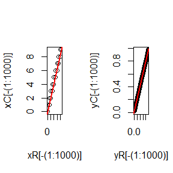

```r
xR<-x1[,1]
xC<-x2[,1]
yR<-x1[,2]
yC<-x2[,2]
par(mfrow=c(1,2))
qqplot(xR[-(1:1000)],xC[-(1:1000)])
abline(0,1,col='red',lwd=2)
qqplot(yR[-(1:1000)],yC[-(1:1000)])
abline(0,1,col='red',lwd=2)
```

From the plot, it appears that two marginal distributions of one random numbers are in approximate agreement with the other.

```r
library(microbenchmark)
ts<-microbenchmark(gibR=gibbsR(5000),gibC=gibbs_C(5000))
summary(ts)[,c(1,3,5,6)]
```

```
##   expr       lq  median       uq
## 1 gibR 23.95980 29.6722 31.12140
## 2 gibC  1.62745  1.6919  1.78175
```

We get much faster using Rcpp than pure R language.